# STAT 118: Homework E

Making plots with `ggplot2`: histograms, boxplots, line graphs

```r
#LOAD PACKAGES
library(tidyverse)
```

Some of the tools you will need to use to recreate these plots you have not learned in class yet. That is on purpose. Part of this assignment is finding the information yourself. This can be from a Google search, in drop-in tutoring, or in office hours. Part of the struggle with figuring out new coding syntax is finding the words you need to even do the search.

*Use AI at your own discretion (I would recommend not at all) and be sure to cite any AI use at the end of your homework.*

# 1. Iris Side-by-Side Boxplot

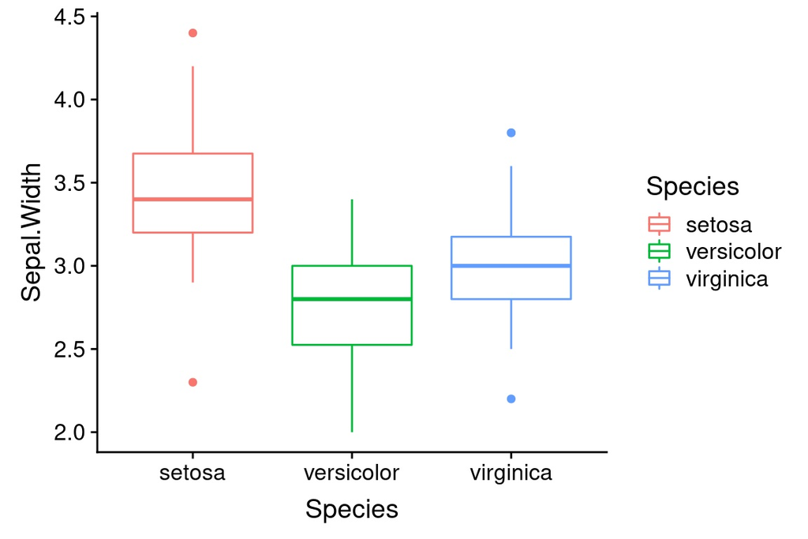

```r
#load the iris dataset
data("iris")
```

# 2. Gapminder Barplot

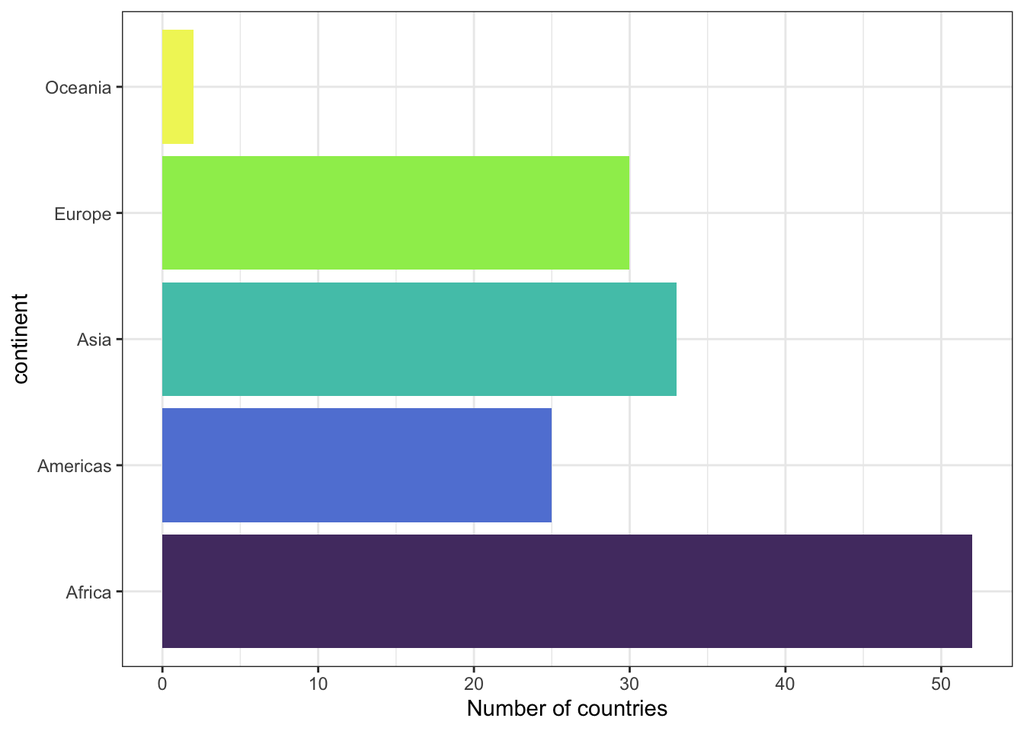

```r
#load the gapminder dataset
library(gapminder)
data("gapminder")
```

# 3. Gapminder Line Graph

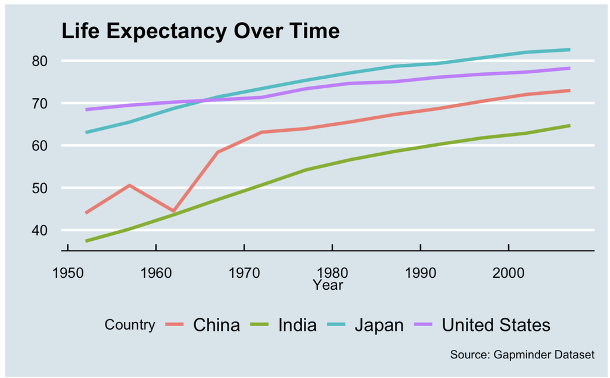

```r
library(ggthemes) # you might need this to help with the theme...
```

# 4. Penguins Histogram

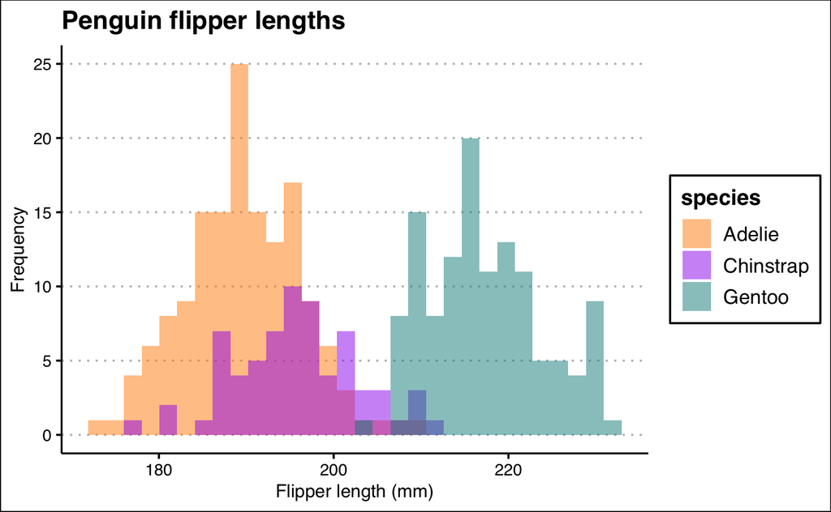

```r
#Load Penguins Data
library(palmerpenguins)
data("penguins")
```

# In class exersize

Choose one numeric variable from the possum dataset. Create two different distribution plots of that variable (choose from: histogram, density, boxplot, violin). Filter for only one of the populations and then compare across a different grouping variable (other than `Population`).

- Change the theme
- Change the colors

Then write 3–4 sentences:

- What do you see? (Be specific.)
- What does each plot make clearer?
- What does each plot hide or distort?